← All notes Source: `12_accel_sgd_explained.ipynb`

Get the notebook ↓ Download .ipynb [▶ Open in Colab](https://colab.research.google.com/github/shammun/shammunul-fastai-notes/blob/main/notebooks/12_accel_sgd_explained_colab.ipynb)

# Accelerated SGD - Explained

## What This Notebook Covers

This notebook explores **optimizers** - the algorithms that update neural network weights during training. We'll build several optimizers from scratch to understand how they work.

### Why Optimizers Matter

The basic gradient descent update is:

```
weight = weight - learning_rate * gradient
```

But this simple approach has problems:

| Problem | Description |
| --- | --- |
| **Slow convergence** | Takes many steps to reach minimum |
| **Oscillation** | Bounces back and forth in steep dimensions |
| **Stuck in saddle points** | Gradient is zero but not at minimum |
| **Same LR for all params** | Some params need bigger/smaller updates |

### Optimizers We'll Build

1. **SGD** - Basic stochastic gradient descent with weight decay
2. **Momentum** - Adds velocity to smooth out updates
3. **RMSProp** - Adapts learning rate per parameter
4. **Adam** - Combines momentum and adaptive learning rates

### Learning Rate Schedulers

We'll also cover schedulers that change the learning rate during training:

- **CosineAnnealingLR** - Smooth cosine decay
- **OneCycleLR** - Fast training with super-convergence

Let's dive in!

## Part 1: Setup and Imports

```python
#|default_exp sgd
# This cell marks that code with #|export will be exported to miniai/sgd.py
```

```python
#|export
import torch

# Import our custom modules from previous notebooks
from miniai.datasets import *     # Data loading utilities
from miniai.conv import *         # Convolution helpers
from miniai.learner import *      # Learner class
from miniai.activations import *  # Activation monitoring
from miniai.init import *         # Weight initialization
```

```python
# Standard library imports
import pickle, gzip, math, os, time, shutil
import matplotlib as mpl
import numpy as np
import matplotlib.pyplot as plt

# Fastcore utilities
import fastcore.all as fc
from collections.abc import Mapping
from pathlib import Path
from operator import attrgetter, itemgetter
from functools import partial
from copy import copy
from contextlib import contextmanager

# PyTorch imports
import torchvision.transforms.functional as TF
import torch.nn.functional as F
from torch import tensor, nn, optim
from torch.utils.data import DataLoader, default_collate
from torch.nn import init
from torch.optim import lr_scheduler  # Learning rate schedulers
from torcheval.metrics import MulticlassAccuracy
from datasets import load_dataset, load_dataset_builder

# Our custom modules
from miniai.datasets import *
from miniai.conv import *
from miniai.learner import *
from miniai.activations import *
from miniai.init import *
```

```python
from fastcore.test import test_close

# Configure PyTorch display
torch.set_printoptions(precision=2, linewidth=140, sci_mode=False)
torch.manual_seed(1)

# Disable logging warnings
import logging
logging.disable(logging.WARNING)

# Set seed for reproducibility
set_seed(42)
```

## Part 2: Data Setup

We'll use Fashion MNIST with normalized inputs (as we learned in the previous notebook).

```python
# Dataset configuration
xl, yl = 'image', 'label'  # Column names
name = "zalando-datasets/fashion_mnist"      # Dataset name
dsd = load_dataset(name)    # Load from Hugging Face

# Batch size
bs = 1024

# Normalization constants (computed from dataset)
xmean, xstd = 0.28, 0.35

# Transform: convert to tensor and normalize
@inplace
def transformi(b):
    b[xl] = [(TF.to_tensor(o) - xmean) / xstd for o in b[xl]]

# Create datasets and dataloaders
tds = dsd.with_transform(transformi)
dls = DataLoaders.from_dd(tds, bs, num_workers=4)
```

```python
# Set up callbacks and model configuration
metrics = MetricsCB(accuracy=MulticlassAccuracy())  # Track accuracy
astats = ActivationStats(fc.risinstance(GeneralRelu))  # Monitor activations

# Standard callbacks for training
cbs = [DeviceCB(), metrics, ProgressCB(plot=True), astats]

# GeneralRelu with leak=0.1 and sub=0.4 (from previous notebook)
act_gr = partial(GeneralRelu, leak=0.1, sub=0.4)

# Kaiming init with correct leaky slope
iw = partial(init_weights, leaky=0.1)

# Callbacks for LR finder
lrf_cbs = [DeviceCB(), LRFinderCB()]
```

## Part 3: Optimizers

An **optimizer** is responsible for updating model parameters based on gradients. All optimizers follow this basic pattern:

```
1. Compute gradients (via loss.backward())
2. Update parameters based on gradients
3. Zero out gradients for next iteration
```

## 🛠️ Interactive visualizations — one-time setup

The cells marked **🎮 Interactive** below embed standalone HTML/JS visualizations (stored in the `interactive_viz/` folder next to this notebook) at **full width and ~full viewport height**. Run the next cell once, then run any 🎮 cell.

```python
# ============================================================================
# INTERACTIVE VISUALIZATIONS -- setup (run this cell ONCE).
# Each "🎮 Interactive" cell below loads a standalone HTML file from the
# published copy on GitHub Pages, in an isolated <iframe> (its CSS/JS can't leak
# into the notebook). It is shown FULL WIDTH and auto-fits its content height.
# No local files needed -- the visualizations are read from GitHub.
# ============================================================================
from IPython.display import HTML

def show_viz(path, height="600px"):
    """Embed an interactive visualization full width; it auto-fits its height.
    `path` may be a bare 'interactive_viz/<file>.html' (resolved to the GitHub
    Pages copy) or a full https URL."""
    base = "https://shammun.github.io/shammunul-fastai-notes/notebooks/"
    if not path.startswith("http"):
        path = base + path
    return HTML(
        f'<iframe src="{path}" loading="lazy" allowfullscreen '
        f'style="width:100%;height:{height};border:1px solid #dde5f2;border-radius:12px;'
        f'box-shadow:0 8px 24px rgba(123,92,214,.12);background:#fff;"></iframe>'
        '<script>addEventListener("message",function(e){'
        'if(e.data&&e.data.type==="ce-frame-height"&&e.data.height>50){'
        'var fs=document.querySelectorAll("iframe");for(var i=0;i<fs.length;i++){'
        'if(fs[i].contentWindow===e.source){fs[i].style.height=e.data.height+"px";break;}}}});</script>'
    )
```

[figure not shown]

### SGD (Stochastic Gradient Descent)

The simplest optimizer. Updates each parameter by subtracting the gradient scaled by the learning rate.

**Update Rule:** $$w_{t+1} = w_t - \eta \cdot \nabla L(w_t)$$

Where:

- $w_t$ = current weights
- $\eta$ = learning rate
- $\nabla L(w_t)$ = gradient of loss with respect to weights

```python
class SGD:
    """
    Stochastic Gradient Descent optimizer.

    This is the simplest optimizer - it just subtracts the gradient
    from each parameter, scaled by the learning rate.

    Args:
        params: Iterator of parameters to optimize (usually model.parameters())
        lr: Learning rate - how big of a step to take
        wd: Weight decay - L2 regularization strength (default: 0)
    """
    def __init__(self, params, lr, wd=0.):
        # Convert params iterator to list (so we can iterate multiple times)
        params = list(params)
        # fc.store_attr() stores all arguments as instance attributes
        # equivalent to: self.params = params; self.lr = lr; self.wd = wd
        fc.store_attr()
        # Step counter (used by some optimizers for bias correction)
        self.i = 0

    def step(self):
        """
        Perform one optimization step.

        For each parameter:
        1. Apply regularization (weight decay)
        2. Apply optimization (gradient descent)
        """
        # torch.no_grad() prevents gradient tracking for these operations
        # We don't want to compute gradients of the update itself!
        with torch.no_grad():
            for p in self.params:
                self.reg_step(p)  # Regularization
                self.opt_step(p)  # Optimization
        self.i += 1  # Increment step counter

    def opt_step(self, p):
        """
        The actual gradient descent update.

        Formula: param = param - lr * gradient

        The -= operator modifies p in place.
        """
        p -= p.grad * self.lr

    def reg_step(self, p):
        """
        Apply weight decay (L2 regularization).

        Formula: param = param * (1 - lr * wd)

        This shrinks weights slightly each step, preventing them
        from growing too large (helps prevent overfitting).
        """
        if self.wd != 0:
            p *= 1 - self.lr * self.wd

    def zero_grad(self):
        """
        Zero out all gradients.

        Must be called before computing new gradients, because
        PyTorch accumulates gradients by default.
        """
        for p in self.params:
            p.grad.data.zero_()  # In-place zero
```

# Regularization Followed by Optimization — Why and How?

## The Code in Question

From the `SGD` class in `12_accel_sgd_explained.ipynb`:

```
def step(self):
    with torch.no_grad():
        for p in self.params:
            self.reg_step(p)  # Step 1: Regularization (weight decay)
            self.opt_step(p)  # Step 2: Optimization (gradient descent)
    self.i += 1
```

This raises three natural questions:

1. What does each step actually do?
2. Why are both needed?
3. Why does regularization come *before* optimization?

## What Each Step Does

### `reg_step` — Regularization (Weight Decay)

```
def reg_step(self, p):
    if self.wd != 0:
        p *= 1 - self.lr * self.wd
```

This has **nothing to do with gradients or the loss function**. It simply shrinks every weight slightly toward zero by multiplying it by a factor just below 1.0.

**Concrete example:** If `lr = 0.01` and `wd = 0.01`, then the decay factor is `1 - 0.01 × 0.01 = 0.9999`. A weight of `5.0` becomes `5.0 × 0.9999 = 4.9995`. It's a tiny nudge, but accumulated over thousands of steps, it prevents weights from growing unboundedly large.

**Purpose:** Capacity control. Large weights mean the model is memorizing noise in the training data. By constantly pulling weights toward zero, we force the model to only keep weights large if the gradient signal (from the data) is strong enough to push them back up.

### `opt_step` — Optimization (Gradient Descent)

```
def opt_step(self, p):
    p -= self.lr * p.grad
```

This is the actual learning step. The gradient `p.grad` tells us the direction in which the loss increases. We move the weight in the opposite direction (hence the minus sign), scaled by the learning rate.

**Purpose:** Minimize the loss function. Without this step, the model never learns anything from the data.

## Why Both Steps Are Needed

|  | Regularization alone | Optimization alone | Both together |
| --- | --- | --- | --- |
| **What happens** | All weights decay to zero | Weights fit training data, potentially overfitting | Weights learn from data while being kept small |
| **Training loss** | Increases (model forgets) | Decreases (model learns) | Decreases (model learns) |
| **Test loss** | Bad (underfitting) | Can be bad (overfitting) | Better (generalization) |

Think of it as two competing forces:

- **Optimization** pushes weights wherever the gradient says will reduce the loss — it doesn't care about weight magnitude.
- **Regularization** pulls weights toward zero — it doesn't care about the loss at all.

The balance between these two forces is what produces a model that **learns the true signal** (optimization) **without memorizing noise** (regularization). A weight stays large only if the gradient pressure from the data is strong enough to overcome the constant decay.

## Why Regularization Comes *Before* Optimization

This ordering implements **decoupled weight decay**, the key idea behind AdamW (Loshchilov & Hutter, 2019). To understand why the order matters, let's compare two approaches.

### Approach 1: Coupled (L2 Regularization — the old way)

In classical L2 regularization, we add a penalty term to the loss:

$$\mathcal{L}_{\text{total}} = \mathcal{L}_{\text{data}} + \frac{\lambda}{2} \|w\|^2$$

Taking the gradient:

$$\nabla \mathcal{L}_{\text{total}} = \nabla \mathcal{L}_{\text{data}} + \lambda w$$

The update becomes:

```
grad += wd * weight        # regularization is INSIDE the gradient
weight -= lr * grad        # single combined step
```

**Problem:** The regularization effect is now entangled with the gradient. In adaptive optimizers like Adam, the gradient gets divided by a running average of squared gradients. This means the weight decay penalty also gets divided by this term, effectively weakening regularization for parameters with large gradients. The regularization strength becomes dependent on the optimization dynamics — you can't tune them independently.

### Approach 2: Decoupled Weight Decay (what our code does)

```
weight *= (1 - lr * wd)    # Step 1: shrink directly, no gradient involved
weight -= lr * grad        # Step 2: gradient update on the already-decayed weight
```

**Advantage:** The two operations are completely independent. The shrinkage applied in Step 1 is a fixed fraction of the current weight — it doesn't interact with gradient magnitudes, momentum buffers, or adaptive learning rate terms. This means:

- You can tune `wd` and `lr` independently
- Weight decay behaves consistently regardless of the optimizer (SGD, Adam, RMSProp)
- The regularization effect doesn't get distorted by adaptive gradient scaling

### Why Regularization Specifically Comes *First*

If we reversed the order (optimize then regularize), the decay would be applied to the *already-updated* weight:

```
# Hypothetical reversed order:
weight -= lr * grad              # optimize first
weight *= (1 - lr * wd)         # then decay the updated weight
```

This means the gradient update itself gets partially decayed in the same step it was applied. The decay is now acting on `(old_weight - lr * grad)` instead of just `old_weight`. The optimization step and the regularization step are no longer truly independent — the size of the gradient update affects how much regularization is applied, which re-introduces a subtle coupling.

By regularizing first, each operation targets a clean, well-defined quantity:

1. **`reg_step`** sees the weight from the previous step and decays it → `w' = w × (1 - lr × wd)`
2. **`opt_step`** sees the decayed weight and applies the gradient → `w'' = w' - lr × grad`

The gradient update is applied to a weight that has already been regularized, keeping the two concerns cleanly separated.

## Summary

```
┌─────────────────────────────────────────────────────────┐
│                    optimizer.step()                      │
│                                                         │
│  ┌──────────────────────┐   ┌────────────────────────┐  │
│  │  1. reg_step (decay) │──▶│  2. opt_step (gradient) │  │
│  │                      │   │                         │  │
│  │  Purpose: Prevent    │   │  Purpose: Learn from    │  │
│  │  overfitting         │   │  data                   │  │
│  │                      │   │                         │  │
│  │  w *= (1 - lr * wd)  │   │  w -= lr * grad        │  │
│  │                      │   │                         │  │
│  │  Uses: NO gradients  │   │  Uses: gradients only   │  │
│  └──────────────────────┘   └────────────────────────┘  │
│                                                         │
│  Order matters: decay first keeps the two operations    │
│  independent (decoupled weight decay / AdamW style)     │
└─────────────────────────────────────────────────────────┘
```

**Key takeaway:** Both steps are essential — regularization controls model complexity while optimization drives learning. Applying regularization first ensures the two mechanisms remain decoupled, making hyperparameter tuning cleaner and the regularization effect consistent across different optimizer variants.

```python
# ============================================================================
# SGD (Stochastic Gradient Descent) Optimizer - Built from Scratch
# ============================================================================
# This class implements the most fundamental optimization algorithm used in
# deep learning. An "optimizer" is the algorithm that decides HOW to update
# the neural network's weights after we compute gradients via backpropagation.
#
# The core idea is simple:
#   new_weight = old_weight - learning_rate * gradient
#
# Think of it like descending a mountain in fog:
#   - You can only feel the slope right under your feet (the gradient)
#   - You take a step downhill proportional to how steep it is
#   - The learning_rate controls how big each step is
#
# "Stochastic" means we compute gradients on random mini-batches of data
# (not the entire dataset), which makes training faster but noisier.
# ============================================================================

class SGD:
    """
    Stochastic Gradient Descent optimizer.

    This is the simplest optimizer - it just subtracts the gradient
    from each parameter, scaled by the learning rate.

    Args:
        params: Iterator of parameters to optimize (usually model.parameters())
        lr: Learning rate - how big of a step to take
        wd: Weight decay - L2 regularization strength (default: 0)
    """

    # --------------------------------------------------------------------------
    # __init__: Constructor - called when we create a new SGD instance
    # --------------------------------------------------------------------------
    # Usage example:
    #   optimizer = SGD(model.parameters(), lr=0.01, wd=0.001)
    #
    # Args:
    #   params: The model's trainable weights/biases. When you call
    #           model.parameters(), PyTorch returns a Python "iterator" -
    #           an object you can loop over ONCE to get each parameter tensor.
    #   lr:     Learning rate - a small positive number (e.g., 0.01, 0.001).
    #           Controls how big each update step is.
    #           Too large = training explodes/diverges.
    #           Too small = training is painfully slow.
    #   wd:     Weight decay strength (default 0.0 = no decay).
    #           This is a regularization technique that slightly shrinks
    #           weights toward zero each step, preventing overfitting.
    #           Typical values: 0.01, 0.001, 0.0001.
    # --------------------------------------------------------------------------
    def __init__(self, params, lr, wd=0.):

        # Convert the params iterator into a Python list.
        # WHY? An iterator can only be looped over ONCE - after that, it's
        # "exhausted" (empty). But we need to loop over the parameters many
        # times (once per training step). Converting to a list lets us
        # iterate over them as many times as we want.
        #
        # Example:
        #   gen = model.parameters()  # This is a one-time-use iterator/generator
        #   list(gen)                 # Now it's a reusable list of tensors
        #                             # e.g., [weight1, bias1, weight2, bias2, ...]
        params = list(params)

        # fc.store_attr() is a convenience function from the fastcore library.
        # It automatically takes ALL the arguments of this __init__ method
        # (params, lr, wd) and stores them as attributes of 'self'.
        #
        # This single line is equivalent to writing all three of these:
        #   self.params = params   # Store the list of parameter tensors
        #   self.lr = lr           # Store the learning rate
        #   self.wd = wd           # Store the weight decay value
        #
        # After this, we can access them anywhere in the class as:
        #   self.params, self.lr, self.wd
        fc.store_attr()

        # Initialize a step counter starting at 0.
        # This counts how many optimization steps we've taken so far.
        # Basic SGD doesn't use this, but child classes like Adam need it
        # for "bias correction" (a mathematical fix for early training steps).
        # We define it here in the parent class so all child classes inherit it.
        self.i = 0

    # --------------------------------------------------------------------------
    # step(): Perform one complete optimization update
    # --------------------------------------------------------------------------
    # This is called once per training batch, AFTER loss.backward() has
    # computed all the gradients. The typical training loop looks like:
    #
    #   for batch in dataloader:
    #       predictions = model(batch)        # Forward pass
    #       loss = loss_function(predictions)  # Compute loss
    #       loss.backward()                    # Compute gradients (backprop)
    #       optimizer.step()                   # <-- THIS METHOD: update weights
    #       optimizer.zero_grad()              # Clear gradients for next batch
    # --------------------------------------------------------------------------
    def step(self):
        """
        Perform one optimization step.

        For each parameter:
        1. Apply regularization (weight decay)
        2. Apply optimization (gradient descent)
        """

        # torch.no_grad() creates a "context manager" (the 'with' block) that
        # temporarily disables PyTorch's automatic gradient tracking.
        #
        # WHY IS THIS NECESSARY?
        # PyTorch normally tracks every mathematical operation on tensors so it
        # can later compute gradients via backpropagation. But here we're
        # UPDATING the weights, not doing a forward pass. We don't want PyTorch
        # to try to compute "gradients of the weight update" - that would:
        #   1. Waste memory (storing unnecessary computation graph)
        #   2. Waste time (tracking operations we don't need gradients for)
        #   3. Potentially corrupt the actual gradients we need
        #
        # Everything inside this 'with' block runs without gradient tracking.
        with torch.no_grad():
```

```python
            # Loop over every trainable parameter in the model.
            # Each 'p' is a PyTorch tensor (e.g., a weight matrix or bias vector).
            # A typical CNN might have dozens of parameter tensors:
            #   - Conv layer 1 weights (shape: [32, 1, 3, 3])
            #   - Conv layer 1 biases (shape: [32])
            #   - Conv layer 2 weights (shape: [64, 32, 3, 3])
            #   - ... and so on
            for p in self.params:

                # STEP 1: Apply regularization (weight decay)
                # This slightly shrinks the parameter values toward zero.
                # Done BEFORE the gradient step (this is "decoupled" weight decay).
                self.reg_step(p)

                # STEP 2: Apply the gradient descent update
                # This moves the parameter in the direction that reduces the loss.
                self.opt_step(p)

        # After updating ALL parameters, increment the step counter.
        # This tracks how many times step() has been called (i.e., how many
        # batches we've processed). Used by Adam for bias correction.
        self.i += 1

    # --------------------------------------------------------------------------
    # opt_step(): The core gradient descent update for a single parameter
    # --------------------------------------------------------------------------
    # This is the heart of the optimizer. For basic SGD, it's just:
    #   parameter = parameter - learning_rate * gradient
    #
    # This method is designed to be OVERRIDDEN by child classes (Momentum,
    # RMSProp, Adam) to implement more sophisticated update rules.
    #
    # Args:
    #   p: A single parameter tensor (e.g., one weight matrix).
    #      After loss.backward(), p.grad contains the gradient of the loss
    #      with respect to this parameter.
    # --------------------------------------------------------------------------
    def opt_step(self, p):
        """
        The actual gradient descent update.

        Formula: param = param - lr * gradient

        The -= operator modifies p in place.
        """

        # This is the fundamental gradient descent equation:
        #   p = p - (learning_rate * gradient)
        #
        # WHAT DOES EACH PART MEAN?
        #   p.grad:     The gradient - tells us the DIRECTION and MAGNITUDE of
        #               steepest increase in the loss. Computed by loss.backward().
        #               If p.grad is positive, increasing p would increase the loss,
        #               so we want to DECREASE p (hence the subtraction).
        #
        #   self.lr:    The learning rate - a scalar that controls step size.
        #               Multiplying the gradient by lr scales how big our update is.
        #
        #   p -= ...:   The -= operator modifies p IN PLACE (directly changes the
        #               tensor's values in memory). This is equivalent to:
        #                 p.data = p.data - (p.grad * self.lr)
        #               We use in-place operations because:
        #                 1. We're inside torch.no_grad(), so it's safe
        #                 2. It's more memory-efficient (no temporary tensor)
        #                 3. The model's reference to this tensor still works
        #
        # EXAMPLE:
        #   If p = tensor([3.0, -1.0]) and p.grad = tensor([0.5, -0.2]) and lr = 0.1:
        #   p = [3.0, -1.0] - 0.1 * [0.5, -0.2]
        #   p = [3.0, -1.0] - [0.05, -0.02]
        #   p = [2.95, -0.98]
        #   The first weight decreased (gradient was positive = loss was increasing)
        #   The second weight increased (gradient was negative = loss was decreasing)
        p -= p.grad * self.lr

    # --------------------------------------------------------------------------
    # reg_step(): Apply weight decay regularization to a single parameter
    # --------------------------------------------------------------------------
    # Weight decay is a regularization technique that prevents weights from
    # growing too large, which helps prevent overfitting.
    #
    # INTUITION: Without regularization, some weights might grow very large to
    # memorize the training data perfectly. By gently shrinking all weights
    # toward zero each step, we encourage the model to find simpler solutions
    # that generalize better to new data.
    #
    # NOTE: This implements "decoupled" weight decay (as in AdamW), NOT
    # L2 regularization. The difference matters for adaptive optimizers like Adam:
    #   - Weight decay:       param *= (1 - lr * wd)    [shrink directly]
    #   - L2 regularization:  grad += wd * param        [add to gradient]
    # For basic SGD these are mathematically equivalent, but for Adam they
    # produce different results. Decoupled weight decay (used here) is
    # generally considered better practice.
    #
    # Args:
    #   p: A single parameter tensor to regularize
    # --------------------------------------------------------------------------
    def reg_step(self, p):
        """
        Apply weight decay (L2 regularization).

        Formula: param = param * (1 - lr * wd)

        This shrinks weights slightly each step, preventing them
        from growing too large (helps prevent overfitting).
        """

        # Only apply weight decay if wd is non-zero.
        # WHY THIS CHECK? If wd=0 (the default), there's no regularization
        # to apply. Skipping the multiplication saves computation and avoids
        # any tiny floating-point rounding errors from multiplying by 1.0.
        if self.wd != 0:

            # Multiply every value in the parameter tensor by (1 - lr * wd).
            # Since lr and wd are both small positive numbers, (1 - lr * wd)
            # is a number very close to 1 but slightly less (e.g., 0.9999).
            #
            # This gently shrinks ALL weights toward zero by a tiny fraction
            # at every step.
            #
            # EXAMPLE:
            #   If lr=0.01, wd=0.01:
            #     shrink_factor = 1 - 0.01 * 0.01 = 1 - 0.0001 = 0.9999
            #     A weight of 5.0 becomes: 5.0 * 0.9999 = 4.9995
            #     A weight of -3.0 becomes: -3.0 * 0.9999 = -2.9997
            #
            #   Over many steps, this prevents weights from drifting too far
            #   from zero, unless the gradient signal is strong enough to
            #   push them there (meaning they're truly needed).
            #
            # The *= operator modifies p IN PLACE (same as p = p * value).
            p *= 1 - self.lr * self.wd
```

```python
    # --------------------------------------------------------------------------
    # zero_grad(): Clear all stored gradients
    # --------------------------------------------------------------------------
    # This MUST be called before computing new gradients (i.e., before
    # loss.backward() on the next batch).
    #
    # WHY? PyTorch ACCUMULATES gradients by default. If you call
    # loss.backward() twice without zeroing, the second call ADDS to the
    # existing gradients rather than replacing them. This is occasionally
    # useful (e.g., gradient accumulation for simulating larger batch sizes),
    # but normally we want fresh gradients for each batch.
    #
    # Typical training loop:
    #   optimizer.zero_grad()       # Clear old gradients
    #   loss = compute_loss(batch)  # Forward pass
    #   loss.backward()             # Compute NEW gradients
    #   optimizer.step()            # Update weights using those gradients
    # --------------------------------------------------------------------------
    def zero_grad(self):
        """
        Zero out all gradients.

        Must be called before computing new gradients, because
        PyTorch accumulates gradients by default.
        """

        # Loop over every parameter in the model
        for p in self.params:

            # Set all values in this parameter's gradient tensor to zero.
            #
            # BREAKDOWN OF p.grad.data.zero_():
            #
            #   p.grad:       The gradient tensor stored on this parameter.
            #                 After loss.backward(), this holds ∂loss/∂p.
            #                 Same shape as p itself.
            #
            #   .data:        Accesses the raw tensor data WITHOUT gradient
            #                 tracking. We use .data here to ensure this
            #                 zeroing operation isn't recorded in PyTorch's
            #                 computation graph (we don't need gradients of
            #                 the zeroing operation itself).
            #
            #   .zero_():     An IN-PLACE operation (indicated by the trailing
            #                 underscore '_', a PyTorch convention) that sets
            #                 every element in the tensor to 0.0.
            #                 In-place means it modifies the existing tensor
            #                 rather than creating a new one (saves memory).
            #
            # After this, p.grad is a tensor of all zeros, ready for the
            # next call to loss.backward() to fill in fresh gradient values.
            p.grad.data.zero_()
```

### Weight Decay vs L2 Regularization

These are often confused but are slightly different:

**Weight Decay** (what we implemented):

```
weight -= lr * wd * weight  # Shrink weights directly
# or equivalently:
weight *= 1 - lr * wd
```

**L2 Regularization** (adds to gradient):

```
weight.grad += wd * weight  # Add penalty to gradient
```

For basic SGD these are equivalent, but for Adam they behave differently! AdamW uses proper weight decay, which works better.

### 🎮 Interactive: anatomy of one SGD step — with weight decay

One `opt.step()`, dissected on a live loss curve. A single weight walks downhill while you watch `reg_step` and `opt_step` fire in order.

**What to try**

- Click the stage chips — **⓪ gradients → ① reg_step → ② opt_step → ③ zero_grad** — each highlights the matching lines of the `SGD` class.
- Press **▶ Play** and let it loop: every cycle is one mini-batch, and the hops shrink as the slope flattens.
- Set **wd = 0.1 or 0.3** and watch the ball settle at the dashed teal line, *not* the loss minimum — weight decay literally moves the optimum.
- The curve's curvature is 1, so overshoot starts past **lr = 1** and divergence past **lr = 2**: try 1.5 (bouncing), then 2.1 (bounces grow until it slams the edges).

```python
# ============================================================================
# INTERACTIVE -- run this cell. It loads ./interactive_viz/sgd_step_anatomy.html
# at full width, sized to fit the visualization (setup cell near the top required).
# Keep the 'interactive_viz' folder in the SAME directory as this notebook.
# ============================================================================
show_viz("interactive_viz/sgd_step_anatomy.html", height="760px")
```

[interactive chart not shown]

```python
# Train with our SGD optimizer
set_seed(42)
model = get_model(act_gr, norm=nn.BatchNorm2d).apply(iw)

# TrainLearner uses opt_func to create the optimizer
# We pass our SGD class (not an instance)
learn = TrainLearner(model, dls, F.cross_entropy, lr=0.4, cbs=cbs, opt_func=SGD)
```

| accuracy | loss | epoch | train |
| --- | --- | --- | --- |
| 0.769 | 0.647 | 0 | train |
| 0.823 | 0.497 | 0 | eval |
| 0.844 | 0.430 | 1 | train |
| 0.841 | 0.441 | 1 | eval |
| 0.862 | 0.380 | 2 | train |
| 0.856 | 0.402 | 2 | eval |

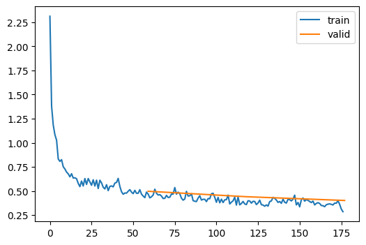

```python
# Train for 3 epochs
learn.fit(3)
```

## Part 4: Momentum

Basic SGD can oscillate when the loss surface has different curvatures in different directions. **Momentum** smooths out these oscillations by maintaining a "velocity" that accumulates over time.

### Intuition: Rolling Ball

Imagine a ball rolling down a hill:

- Without momentum: Ball moves directly downhill, can oscillate in valleys
- With momentum: Ball builds up speed, smoothly rolls through valleys

### Exponential Moving Average

Momentum uses an exponential moving average (EMA) of gradients:

$$v_t = \beta \cdot v_{t-1} + (1-\beta) \cdot g_t$$$$w_{t+1} = w_t - \eta \cdot v_t$$

Where:

- $v_t$ = velocity (accumulated gradient)
- $\beta$ = momentum coefficient (typically 0.9)
- $g_t$ = current gradient

# Momentum — Explained

## The Problem Momentum Solves

With plain SGD, the update at each step depends *only* on the current batch's gradient:

```
weight -= lr * gradient
```

This creates two problems:

1. **Noisy gradients:** Each mini-batch gives a slightly different gradient. The updates jitter around, wasting steps on noise rather than making consistent progress toward the minimum.
2. **Oscillation in narrow valleys:** If the loss surface is steep in one direction and shallow in another (like a narrow ravine), SGD bounces back and forth across the steep walls while making slow progress along the shallow floor.

```
Without Momentum:            With Momentum:

    ↗ ↙ ↗ ↙                    →→→→→
   ↗   ↙   ↗                  →→→→→→
  ↗     ↙                    →→→→→→→
       (oscillates)          (smooth progress)
```

Momentum fixes both problems by replacing the raw gradient with a **smoothed running average** of recent gradients.

## The Core Idea: Exponential Moving Average (EMA)

Before understanding momentum, we need to understand EMA — the mathematical tool it relies on.

Given a noisy sequence of values $y_1, y_2, y_3, \ldots$, the exponential moving average is:

$$\text{avg}_t = \beta \cdot \text{avg}_{t-1} + (1 - \beta) \cdot y_t$$

Where $\beta$ controls how much smoothing is applied:

| $\beta$ | Behavior |
| --- | --- |
| 0.5 | Responds quickly, still noisy |
| 0.7 | Moderate smoothing |
| 0.9 | Very smooth — **most common choice** |
| 0.99 | Extremely smooth but slow to react to changes |

**How to read the formula:** The new average is a weighted blend of the old average ($\beta$ weight) and the new observation ($(1-\beta)$ weight). With $\beta = 0.9$, the average is 90% memory and 10% new data. This means each new observation nudges the average a little, but sudden spikes or noise get dampened.

**How far back does EMA look?** The effective window is approximately $\frac{1}{1-\beta}$ steps. So $\beta = 0.9$ averages roughly over the last 10 gradients, and $\beta = 0.99$ averages over the last 100.

### EMA Visualization (from the notebook)

The notebook plots EMA at different $\beta$ values over noisy parabolic data:

```
avg = 0
for yi in ys:
    avg = beta * avg + (1 - beta) * yi   # EMA formula
    res.append(avg)
```

## How Momentum Uses EMA

The Momentum optimizer applies EMA to the *gradients* instead of using them raw:

$$v_t = \beta \cdot v_{t-1} + (1 - \beta) \cdot g_t$$$$w_{t+1} = w_t - \eta \cdot v_t$$

Where:

- $v_t$ = velocity (the EMA of gradients) — this is the "momentum"
- $\beta$ = momentum coefficient (typically 0.9)
- $g_t$ = current gradient from this batch
- $\eta$ = learning rate

Instead of stepping in the direction of this batch's gradient, we step in the direction of the *smoothed* gradient — the accumulated trend.

## The Code

```
class Momentum(SGD):
    def __init__(self, params, lr, wd=0., mom=0.9):
        super().__init__(params, lr=lr, wd=wd)
        self.mom = mom

    def opt_step(self, p):
        # Initialize velocity to zeros on first step
        if not hasattr(p, 'grad_avg'):
            p.grad_avg = torch.zeros_like(p.grad)

        # EMA update: blend old velocity with new gradient
        p.grad_avg = p.grad_avg * self.mom + p.grad * (1 - self.mom)

        # Step using smoothed gradient instead of raw gradient
        p -= self.lr * p.grad_avg
```

### Line-by-line breakdown

**`class Momentum(SGD)`** — Inherits from SGD, so it gets `reg_step` (weight decay) and the `step()` loop for free. Only `opt_step` is overridden.

**`if not hasattr(p, 'grad_avg')`** — On the very first optimization step, we need to create the velocity buffer. It's stored directly on the parameter tensor as an attribute (`p.grad_avg`), so each parameter has its own independent velocity. Initialized to zeros because we have no history yet.

**`p.grad_avg = p.grad_avg * self.mom + p.grad * (1 - self.mom)`** — This is the EMA formula. With `mom=0.9`:

- 90% of the velocity comes from accumulated history
- 10% comes from the current gradient
- This means a single noisy gradient only has 10% influence on the update direction

**`p -= self.lr * p.grad_avg`** — We update the weight using the smoothed velocity, not the raw gradient.

### 1. Noise Reduction

Each mini-batch gradient is a noisy estimate of the true gradient (the gradient you'd get by computing over the entire dataset). By averaging many recent gradients, momentum gets closer to the true gradient direction.

**Analogy:** Imagine asking 10 people for directions. Each person gives a slightly different answer (noise), but if you average all their answers, you get a much more reliable direction than asking just one person.

### 2. Acceleration in Consistent Directions

When gradients consistently point in the same direction across steps, the velocities accumulate and the effective step size *grows*. When gradients oscillate (pointing left, then right, then left), the opposing signals cancel out and the effective step size *shrinks*.

**Numerical example with $\beta = 0.9$:**

Suppose the gradient in the x-direction is consistently +1.0 every step, and in the y-direction it alternates between +1.0 and -1.0.

After many steps, the x-velocity converges to:

$$v_x = (1-\beta) \cdot g_x \cdot \frac{1}{1-\beta} = g_x = 1.0$$

But the y-velocity oscillates around:

The consistent x-direction gets a full update of 1.0, while the oscillating y-direction gets damped to ±0.1. The optimizer automatically accelerates along the ravine floor and suppresses the bouncing across the walls.

### 3. Escaping Local Minima and Saddle Points

Because velocity accumulates, the optimizer can "roll through" shallow local minima and flat saddle points where the gradient is near zero. A ball with momentum doesn't stop the instant the slope flattens — it keeps going. Similarly, the accumulated velocity carries the parameters past points where a zero gradient would stall plain SGD.

## Practical Impact: Higher Learning Rates

The notebook demonstrates a direct consequence of momentum's smoothing:

```
# Plain SGD — limited to lr=0.4
learn = TrainLearner(model, dls, F.cross_entropy, lr=0.4, opt_func=SGD)

# Momentum — can use lr=1.5 (almost 4x higher!)
learn = TrainLearner(model, dls, F.cross_entropy, lr=1.5, opt_func=Momentum)
```

Because momentum damps oscillations, the optimizer can tolerate much larger learning rates without diverging. Larger learning rates mean bigger steps per iteration, which means faster convergence. This is the main practical benefit — momentum doesn't just smooth the path, it lets you *run faster*.

## How Momentum Connects to the Rest of the Notebook

Momentum is the first building block beyond plain SGD. The subsequent optimizers in the notebook build on top of it:

```
SGD
 │
 ├── Momentum ──── Adds EMA of gradients (1st moment)
 │                    ↓
 ├── RMSProp  ──── Adds EMA of squared gradients (2nd moment)
 │                    ↓
 └── Adam     ──── Combines Momentum + RMSProp + bias correction
```

- **RMSProp** uses a similar EMA, but on *squared* gradients. It adapts the learning rate per-parameter — parameters with large gradients get smaller updates, and vice versa.
- **Adam** literally combines the momentum velocity ($v_t$, the EMA of gradients) with the RMSProp scaling ($s_t$, the EMA of squared gradients), plus adds bias correction to fix the early-step underestimation caused by initializing both to zero.

So understanding momentum's EMA is the key insight — once you grasp it, RMSProp and Adam are straightforward extensions of the same idea applied to different quantities.

## Summary

| Aspect | Plain SGD | SGD + Momentum |
| --- | --- | --- |
| **Update uses** | Current gradient only | EMA of recent gradients |
| **Noise handling** | Fully exposed to batch noise | Smoothed out |
| **Oscillation** | Bounces in narrow valleys | Damped automatically |
| **Saddle points** | Can get stuck (zero gradient) | Rolls through on accumulated velocity |
| **Typical learning rate** | Lower (e.g., 0.4) | Higher (e.g., 1.5) |
| **State per parameter** | None | One buffer (`grad_avg`) |
| **Key hyperparameter** | — | `mom` (typically 0.9) |

**The one-sentence version:** Momentum replaces each step's noisy gradient with a smoothed trend line of recent gradients, which damps oscillations, allows higher learning rates, and accelerates convergence in consistent directions.

### Visualizing Exponential Moving Average

Let's see how different $\beta$ values affect smoothing.

```python
# Create noisy data
xs = torch.linspace(-4, 4, 100)  # x values from -4 to 4
ys = 1 - (xs/3) ** 2 + torch.randn(100) * 0.1  # Parabola with noise
```

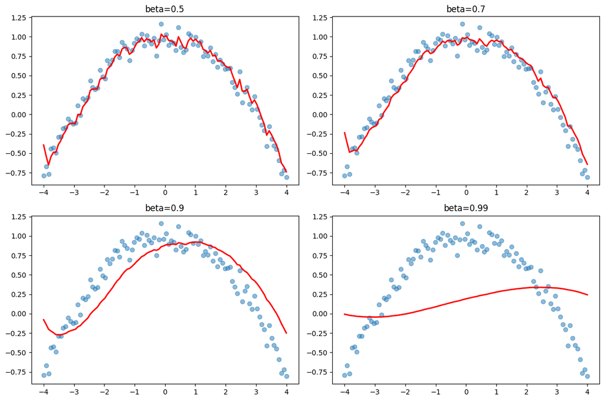

```python
# Plot EMA with different beta values
_, axs = plt.subplots(2, 2, figsize=(12, 8))
betas = [0.5, 0.7, 0.9, 0.99]  # Different momentum values

for beta, ax in zip(betas, axs.flatten()):
    ax.scatter(xs, ys, alpha=0.5)  # Plot raw noisy data

    # Compute exponential moving average
    avg = 0  # Initialize average
    res = []  # Store results
    for yi in ys:
        # EMA formula: new_avg = beta * old_avg + (1-beta) * new_value
        avg = beta * avg + (1 - beta) * yi
        res.append(avg)

    ax.plot(xs, np.array(res), color='red', linewidth=2)  # Plot smoothed
    ax.set_title(f'beta={beta}')

plt.tight_layout()
```

**What we see:**

| Beta | Effect |
| --- | --- |
| 0.5 | Responds quickly but still noisy |
| 0.7 | Moderate smoothing |
| 0.9 | Very smooth (most common choice) |
| 0.99 | Extremely smooth but slow to respond |

Higher $\beta$ = more smoothing = slower response to changes.

```python
class Momentum(SGD):
    """
    SGD with Momentum.

    Instead of using the raw gradient, we use an exponential moving
    average of gradients. This smooths out noisy gradients and helps
    accelerate in consistent directions.

    Args:
        params: Parameters to optimize
        lr: Learning rate
        wd: Weight decay (default: 0)
        mom: Momentum coefficient (default: 0.9)
    """
    def __init__(self, params, lr, wd=0., mom=0.9):
        # Call parent class __init__
        super().__init__(params, lr=lr, wd=wd)
        self.mom = mom  # Store momentum coefficient

    def opt_step(self, p):
        """
        Optimization step with momentum.

        Algorithm:
        1. If first time, initialize grad_avg to zeros
        2. Update grad_avg with EMA: grad_avg = mom*grad_avg + (1-mom)*grad
        3. Update param using grad_avg instead of raw grad
        """
        # Initialize gradient average if not exists
        # We store it as an attribute on the parameter tensor itself
        if not hasattr(p, 'grad_avg'):
            p.grad_avg = torch.zeros_like(p.grad)

        # Update exponential moving average of gradients
        # grad_avg = momentum * old_avg + (1-momentum) * new_gradient
        p.grad_avg = p.grad_avg * self.mom + p.grad * (1 - self.mom)

        # Update parameters using the averaged gradient
        p -= self.lr * p.grad_avg
```

### Why Momentum Helps

```
Without Momentum:            With Momentum:

    ↗ ↙ ↗ ↙                    →→→→→
   ↗   ↙   ↗                  →→→→→→
  ↗     ↙                    →→→→→→→
       (oscillates)          (smooth progress)
```

Momentum averages out the oscillations while preserving the consistent downhill direction.

### 🎮 Interactive: momentum & EMA lab — kill the zigzag

The EMA formula and the ravine problem, side by side and live.

**What to try**

- Walk the rail **⓪→③**: the matching lines of the `Momentum` class light up on the right.
- Drag **β**: watch the purple EMA get smoother (and laggier) on the noisy signal.
- Press **Race ▶**: SGD (orange) zigzags wall-to-wall while Momentum (purple) glides along the ravine floor.
- The default lr = 0.13 sits just under SGD's stability limit (2/15 ≈ 0.133). Slide to **0.15** and race again — SGD diverges, Momentum survives. That's why the notebook trains at lr = 1.5 with momentum vs 0.4 without.

```python
# ============================================================================
# INTERACTIVE -- run this cell. It loads ./interactive_viz/momentum_ema_lab.html
# at full width, sized to fit the visualization (setup cell near the top required).
# Keep the 'interactive_viz' folder in the SAME directory as this notebook.
# ============================================================================
show_viz("interactive_viz/momentum_ema_lab.html", height="780px")
```

[interactive chart not shown]

```python
# Train with Momentum optimizer
# Notice we can use a HIGHER learning rate (1.5 vs 0.4)!
set_seed(42)
model = get_model(act_gr, norm=nn.BatchNorm2d).apply(iw)
learn = TrainLearner(model, dls, F.cross_entropy, lr=1.5, cbs=cbs, opt_func=Momentum)
```

| accuracy | loss | epoch | train |
| --- | --- | --- | --- |
| 0.788 | 0.586 | 0 | train |
| 0.848 | 0.423 | 0 | eval |
| 0.866 | 0.368 | 1 | train |
| 0.867 | 0.378 | 1 | eval |
| 0.883 | 0.320 | 2 | train |
| 0.873 | 0.355 | 2 | eval |

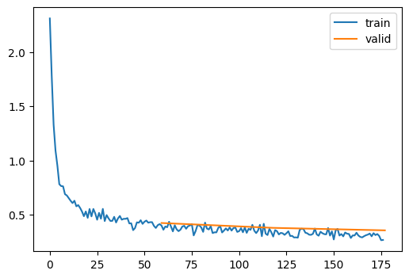

```python
learn.fit(3)
```

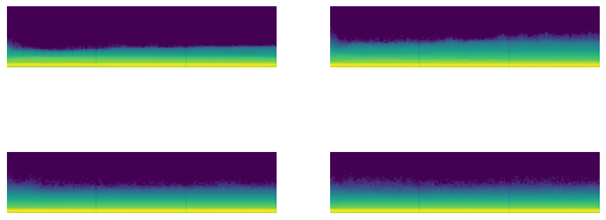

```python
# Check activation statistics
astats.color_dim()
```

With momentum, we can use a much higher learning rate (1.5 vs 0.4) and still train stably!

## Part 5: RMSProp

**RMSProp** (Root Mean Square Propagation) addresses a different problem: different parameters may need different learning rates.

### The Problem

Some parameters have:

- **Large gradients** → need smaller updates
- **Small gradients** → need larger updates

### The Solution: Adaptive Learning Rate

RMSProp divides the learning rate by a running average of gradient magnitudes:

$$s_t = \beta \cdot s_{t-1} + (1-\beta) \cdot g_t^2$$$$w_{t+1} = w_t - \frac{\eta}{\sqrt{s_t} + \epsilon} \cdot g_t$$

Where:

- $s_t$ = running average of squared gradients
- $\beta$ = smoothing coefficient (typically 0.99)
- $\epsilon$ = small constant for numerical stability

```python
class RMSProp(SGD):
    """
    RMSProp optimizer.

    Adapts the learning rate for each parameter based on the
    magnitude of its recent gradients. Parameters with large
    gradients get smaller effective learning rates.

    Args:
        params: Parameters to optimize
        lr: Base learning rate
        wd: Weight decay (default: 0)
        sqr_mom: Momentum for squared gradient average (default: 0.99)
        eps: Small constant for numerical stability (default: 1e-5)
    """
    def __init__(self, params, lr, wd=0., sqr_mom=0.99, eps=1e-5):
        super().__init__(params, lr=lr, wd=wd)
        self.sqr_mom = sqr_mom  # Momentum for squared gradients
        self.eps = eps          # Numerical stability constant

    def opt_step(self, p):
        """
        RMSProp optimization step.

        Algorithm:
        1. Initialize sqr_avg with current gradient squared
        2. Update sqr_avg with exponential moving average (EMA) of squared gradients
        3. Divide gradient by sqrt(sqr_avg) before applying

        This normalizes updates - large gradients are scaled down,
        small gradients are scaled up.
        """
        # Initialize squared gradient average on first step
        if not hasattr(p, 'sqr_avg'):
            p.sqr_avg = p.grad ** 2  # Initialize with current gradient squared

        # Update exponential moving average of squared gradients
        # sqr_avg = sqr_mom * sqr_avg + (1-sqr_mom) * gradient^2
        p.sqr_avg = p.sqr_avg * self.sqr_mom + p.grad ** 2 * (1 - self.sqr_mom)
        # For momentum, we used the moving average of the gradients
        # For RMSProp, we use the moving average of the squared gradients

        # Update parameter with adaptive learning rate
        # The gradient is divided by sqrt(sqr_avg), normalizing it
        # eps prevents division by zero
        p -= self.lr * p.grad / (p.sqr_avg.sqrt() + self.eps)
        # We are dividing by the variance of the gradients
        # This is like dividing by the standard deviation of the gradients
        # So we are normalizing the gradients
        # Then we are subtracting the normalized gradient from the parameter
        # This is like SGD but with adaptive learning rates
        # The learning rate is adjusted based on the variance of the gradients
```

### Why RMSProp Works

```
Parameter A: Large gradients (10, 12, 8, 11, ...)
    sqr_avg ≈ 100
    effective_lr = lr / sqrt(100) = lr / 10 (smaller steps)

Parameter B: Small gradients (0.1, 0.2, 0.1, 0.15, ...)
    sqr_avg ≈ 0.02
    effective_lr = lr / sqrt(0.02) = lr * 7 (larger steps)
```

This helps parameters with small gradients "catch up" to parameters with large gradients.

### 🎮 Interactive: RMSProp — a learning rate per parameter

Exactly the Parameter A / Parameter B story above, running live.

**What to try**

- Watch the top bars: with one lr, the steep parameter's SGD step is far larger than the gentle one's. RMSProp's steps come out nearly equal.
- Press **Race ▶** and compare paths: SGD zigzags/crawls, RMSProp cuts almost diagonally to the minimum.
- Check the teal **effective lr** readouts — this is `lr / (√sqr_avg + eps)` per axis, updating live.
- Stage **①** explains the notebook's subtle trick: `sqr_avg` is initialized with `grad**2`, *not* zeros — see what disaster that avoids.

```python
# ============================================================================
# INTERACTIVE -- run this cell. It loads ./interactive_viz/rmsprop_adaptive_lr.html
# at full width, sized to fit the visualization (setup cell near the top required).
# Keep the 'interactive_viz' folder in the SAME directory as this notebook.
# ============================================================================
show_viz("interactive_viz/rmsprop_adaptive_lr.html", height="780px")
```

[interactive chart not shown]

| accuracy | loss | epoch | train |
| --- | --- | --- | --- |
| 0.769 | 0.659 | 0 | train |
| 0.827 | 0.483 | 0 | eval |
| 0.849 | 0.418 | 1 | train |
| 0.839 | 0.448 | 1 | eval |
| 0.864 | 0.372 | 2 | train |
| 0.856 | 0.400 | 2 | eval |

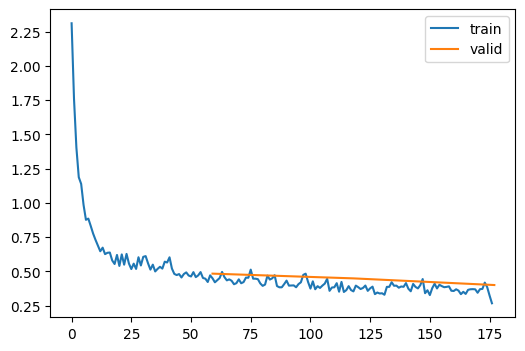

```python
# Train with RMSProp
# Note: RMSProp typically uses MUCH smaller learning rates
set_seed(42)
model = get_model(act_gr, norm=nn.BatchNorm2d).apply(iw)
learn = TrainLearner(model, dls, F.cross_entropy, lr=3e-3, cbs=cbs, opt_func=RMSProp)
learn.fit(3)
```

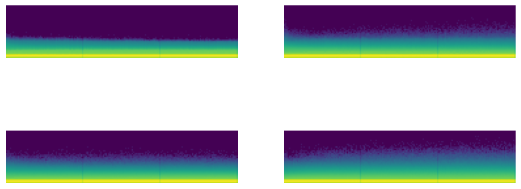

```python
astats.color_dim()
```

## Part 6: Adam

**Adam** (Adaptive Moment Estimation) combines the best of both worlds:

- **Momentum** (first moment) for smooth gradients
- **RMSProp** (second moment) for adaptive learning rates

### Adam Update Rules

$$m_t = \beta_1 \cdot m_{t-1} + (1-\beta_1) \cdot g_t \quad \text{(momentum)}$$$$v_t = \beta_2 \cdot v_{t-1} + (1-\beta_2) \cdot g_t^2 \quad \text{(RMSProp)}$$

### Bias Correction

Since $m_t$ and $v_t$ are initialized to zero, they're biased toward zero in early steps. We correct this:

$$\hat{m}_t = \frac{m_t}{1 - \beta_1^t}$$$$\hat{v}_t = \frac{v_t}{1 - \beta_2^t}$$

### Final Update

$$w_{t+1} = w_t - \frac{\eta}{\sqrt{\hat{v}_t} + \epsilon} \cdot \hat{m}_t$$

```python
class Adam(SGD):
    """
    Adam optimizer.

    Combines momentum (first moment) and RMSProp (second moment)
    with bias correction for both.

    Args:
        params: Parameters to optimize
        lr: Learning rate
        wd: Weight decay (default: 0)
        beta1: Momentum coefficient (default: 0.9)
        beta2: Squared gradient momentum (default: 0.99)
        eps: Numerical stability constant (default: 1e-5)
    """
    def __init__(self, params, lr, wd=0., beta1=0.9, beta2=0.99, eps=1e-5):
        super().__init__(params, lr=lr, wd=wd)
        self.beta1 = beta1  # Momentum coefficient
        self.beta2 = beta2  # Squared gradient coefficient
        self.eps = eps      # Numerical stability

    def opt_step(self, p):
        """
        Adam optimization step.

        Algorithm:
        1. Update first moment (momentum): avg = beta1*avg + (1-beta1)*grad
        2. Bias correct first moment: unbias_avg = avg / (1 - beta1^t)
        3. Update second moment (RMSProp): sqr_avg = beta2*sqr_avg + (1-beta2)*grad^2
        4. Bias correct second moment: unbias_sqr_avg = sqr_avg / (1 - beta2^t)
        5. Update: param -= lr * unbias_avg / sqrt(unbias_sqr_avg)
        """
        # Initialize first moment (momentum) if not exists
        if not hasattr(p, 'avg'):
            p.avg = torch.zeros_like(p.grad.data)

        # Initialize second moment (squared gradients) if not exists
        if not hasattr(p, 'sqr_avg'):
            p.sqr_avg = torch.zeros_like(p.grad.data)

        # Update first moment (momentum)
        p.avg = self.beta1 * p.avg + (1 - self.beta1) * p.grad

        # Bias correction for first moment
        # At step i, the bias is (1 - beta1^(i+1))
        # self.i is the step count from parent class
        unbias_avg = p.avg / (1 - (self.beta1 ** (self.i + 1)))

        # Update second moment (squared gradients)
        p.sqr_avg = self.beta2 * p.sqr_avg + (1 - self.beta2) * (p.grad ** 2)

        # Bias correction for second moment
        unbias_sqr_avg = p.sqr_avg / (1 - (self.beta2 ** (self.i + 1)))

        # Update parameters
        # Uses bias-corrected momentum divided by sqrt of bias-corrected squared average
        p -= self.lr * unbias_avg / (unbias_sqr_avg + self.eps).sqrt()
```

### Why Bias Correction?

```
Without bias correction (early steps):
    Step 1: avg = 0.9*0 + 0.1*grad = 0.1*grad  (too small!)
    Step 2: avg = 0.9*0.1*grad + 0.1*grad = 0.19*grad  (still small)

With bias correction:
    Step 1: unbias_avg = 0.1*grad / (1-0.9^1) = 0.1*grad / 0.1 = grad  (correct!)
    Step 2: unbias_avg = 0.19*grad / (1-0.9^2) = 0.19*grad / 0.19 = grad  (correct!)
```

Bias correction ensures the moving average estimates are unbiased from the start.

### 🎮 Interactive: Adam's bias correction — why ÷(1 − βᵗ)

The table above ("Step 1: avg = 0.1·grad") turned into a scrubbable experiment.

**What to try**

- Drag the **t slider**: the raw EMA (orange) reads only 10% of the true gradient at t=1; the corrected estimate (teal) is exact from step 1.
- Flip the **β chip to 0.99** (Adam's second moment): the needed correction starts at ×100 — and that buffer sits in a *denominator*.
- Walk the rail: stages **①–④** highlight the exact lines of the `Adam` class, including where `self.i` (the step counter from `SGD`) enters.
- Press **▶ Play** to run stages then auto-sweep t.

```python
# ============================================================================
# INTERACTIVE -- run this cell. It loads ./interactive_viz/adam_bias_correction.html
# at full width, sized to fit the visualization (setup cell near the top required).
# Keep the 'interactive_viz' folder in the SAME directory as this notebook.
# ============================================================================
show_viz("interactive_viz/adam_bias_correction.html", height="800px")
```

[interactive chart not shown]

| accuracy | loss | epoch | train |
| --- | --- | --- | --- |
| 0.796 | 0.574 | 0 | train |
| 0.843 | 0.433 | 0 | eval |
| 0.868 | 0.364 | 1 | train |
| 0.867 | 0.372 | 1 | eval |
| 0.884 | 0.318 | 2 | train |
| 0.875 | 0.348 | 2 | eval |

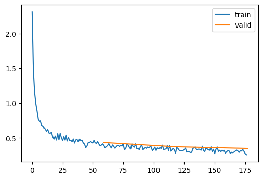

```python
# Train with Adam
set_seed(42)
model = get_model(act_gr, norm=nn.BatchNorm2d).apply(iw)
learn = TrainLearner(model, dls, F.cross_entropy, lr=6e-3, cbs=cbs, opt_func=Adam)
learn.fit(3)
```

### Optimizer Comparison

| Optimizer | Learning Rate | Key Feature |
| --- | --- | --- |
| **SGD** | 0.4 | Simple, baseline |
| **Momentum** | 1.5 | Smooth updates, higher LR |
| **RMSProp** | 0.003 | Adaptive per-parameter LR |
| **Adam** | 0.006 | Best of both worlds |

### 🎮 Interactive: the optimizer race — in 3D

All four optimizers from this notebook on the same loss surface, same lr. Surface height = loss; everyone starts on the **orange ring**, the goal is the **teal ring**.

**What to try**

- Press **Race ▶** on the **Ravine** — this is the comparison table above, animated. The log-scale **loss chart** below the surface shows who's winning at a glance, and the leaderboard ranks runners live (🥇🥈🥉).
- **Drag to rotate / scroll to zoom**, or use the **¾ / Top / Side** view buttons — the Top view makes SGD's zigzag unmistakable.
- Switch to **Saddle**: adaptive methods amplify the near-zero ridge gradients and slide off first; toggle **gradient noise** to see mini-batch noise help everyone escape.
- Try **Banana valley**: momentum overshoots the bends, Adam re-aims each turn — rankings depend on the landscape. Click legend names to hide/show runners; drag the **lr slider** and note SGD needs retuning per surface while RMSProp/Adam barely care.

```python
# ============================================================================
# INTERACTIVE -- run this cell. It loads ./interactive_viz/optimizer_race_3d.html
# at full width, sized to fit the visualization (setup cell near the top required).
# Keep the 'interactive_viz' folder in the SAME directory as this notebook.
# ============================================================================
show_viz("interactive_viz/optimizer_race_3d.html", height="940px")
```

[interactive chart not shown]

## Part 7: Learning Rate Schedulers

The learning rate doesn't have to be constant! **Schedulers** adjust the learning rate during training.

### Why Use Schedulers?

- **High LR early**: Fast progress, explore broadly
- **Low LR late**: Fine-tune, converge precisely

### PyTorch Schedulers

PyTorch provides many built-in schedulers in `torch.optim.lr_scheduler`.

```python
# List all available schedulers (classes that start with uppercase)
' '.join(o for o in dir(lr_scheduler) if o[0].isupper() and o[1].islower())
```

```
'Any ChainedScheduler ConstantLR CosineAnnealingLR CosineAnnealingWarmRestarts Counter CyclicLR ExponentialLR LambdaLR LinearLR Literal MultiStepLR MultiplicativeLR OneCycleLR Optimizer PolynomialLR ReduceLROnPlateau Self SequentialLR StepLR SupportsFloat Tensor TypedDict'
```

Common schedulers:

| Scheduler | Description |
| --- | --- |
| **StepLR** | Reduce LR by factor every N epochs |
| **ExponentialLR** | Multiply LR by gamma each epoch |
| **CosineAnnealingLR** | Cosine decay to minimum LR |
| **OneCycleLR** | 1cycle policy for super-convergence |

```python
# Alternative way to filter (using filter and lambda)
' '.join(filter(lambda x: x[0].isupper() and x[1].islower(), dir(lr_scheduler)))
```

```
'Any ChainedScheduler ConstantLR CosineAnnealingLR CosineAnnealingWarmRestarts Counter CyclicLR ExponentialLR LambdaLR LinearLR Literal MultiStepLR MultiplicativeLR OneCycleLR Optimizer PolynomialLR ReduceLROnPlateau Self SequentialLR StepLR SupportsFloat Tensor TypedDict'
```

### Exploring the Optimizer

Let's look at how PyTorch optimizers store state.

```python
# Create a simple learner to explore optimizer structure
learn = TrainLearner(get_model(), dls, F.cross_entropy, lr=6e-3, cbs=[DeviceCB(), SingleBatchCB()])
learn.fit(1)  # Train for 1 batch
```

```python
# Get the optimizer
opt = learn.opt

# List optimizer attributes (excluding private ones starting with _)
' '.join(o for o in dir(opt) if o[0] != '_')
```

```
'OptimizerPostHook OptimizerPreHook add_param_group defaults load_state_dict param_groups profile_hook_step register_load_state_dict_post_hook register_load_state_dict_pre_hook register_state_dict_post_hook register_state_dict_pre_hook register_step_post_hook register_step_pre_hook state state_dict …
```

# Optimizer Creation vs Execution — and What `learn.opt` Actually Is

## Question 1: Does This Line Run the Optimizer?

```
if self.opt_func: self.opt = self.opt_func(self.model.parameters(), lr)
```

**No — this creates the optimizer, it doesn't run it.** It's calling the optimizer class as a constructor. For example, if `self.opt_func = SGD`, then this becomes:

```
self.opt = SGD(model.parameters(), lr=0.01)
```

This builds the optimizer object and stores it in `self.opt`. No weights are updated yet. The optimizer actually *runs* later, inside the training loop, when `self.step()` is called — which triggers `self.opt.step()`.

### The Full Sequence During `learn.fit()`

```
self.opt = self.opt_func(model.parameters(), lr)   ← CREATE optimizer (just once)
    │
    └── for each epoch:
            for each batch:
                self.predict()        ← forward pass
                self.get_loss()       ← compute loss
                self.backward()       ← compute gradients (loss.backward())
                self.step()           ← self.opt.step() — THIS runs the optimizer
                self.zero_grad()      ← clear gradients for next batch
```

The `self.opt_func` line happens once at the start of `fit()`. The actual optimization — weight decay, EMA updates, gradient steps — happens inside `self.opt.step()`, which is called once per batch, potentially thousands of times during training.

### Creation vs Execution — An Analogy

Think of it like hiring a worker vs the worker doing the job:

```
self.opt = self.opt_func(model.parameters(), lr)   # Hire the worker (create)
# ... later, in the training loop ...
self.opt.step()                                      # Worker does one unit of work (execute)
self.opt.step()                                      # Worker does another unit of work
self.opt.step()                                      # And another...
```

## Question 2: What Is `learn.opt` After Training?

```
learn = TrainLearner(get_model(), dls, F.cross_entropy, lr=6e-3,
                     cbs=[DeviceCB(), SingleBatchCB()])
learn.fit(1)
opt = learn.opt
```

`learn.opt` is the **optimizer object instance** — not a function name, and not a "result" of optimization. It's the living optimizer that was created during `fit()` and used throughout training.

Since `TrainLearner` defaults to `opt_func=optim.SGD`, `learn.opt` is an instance of `torch.optim.SGD`.

### What's Inside This Object

The optimizer object holds **state that persists across steps**:

| What it stores | Example |
| --- | --- |
| Parameter references | Pointers to all the model's weight tensors |
| Learning rate | `lr=6e-3` |
| Weight decay | `wd` value |
| Internal buffers (for Momentum/Adam) | Velocity (`grad_avg`), squared gradient averages (`sqr_avg`) |
| Step counter | How many `.step()` calls have been made |

After `fit(1)` completes, all that accumulated state is still inside `learn.opt`. That's why the notebook grabs it with `opt = learn.opt` — so you can inspect the optimizer's internals after training, like checking the learning rate, parameter groups, or buffer values.

### The Lifecycle of `learn.opt`

```
learn = TrainLearner(...)          # learn.opt doesn't exist yet
    │
learn.fit(1)
    │
    ├── self.opt = self.opt_func(  # learn.opt is CREATED here
    │       model.parameters(), lr)
    │
    ├── training loop runs...      # learn.opt.step() called each batch
    │                              # internal state accumulates
    │
    └── fit() returns              # learn.opt still exists with all its state
    │
opt = learn.opt                    # grab the optimizer object for inspection
```